# Linear Mixed Effects Modeling of BMI and Age

December 3, 2015

## Overview

- Health and Retirement Survey
- Initial Observations
- Linear Mixed Effect Models
- Creating Models
- Graphing Model Fits

## Health and Retirement Survey

-US longitudinal panel study

-N = 20000

-Representative Sample

-Every 2 years

## Splitting by Individuals

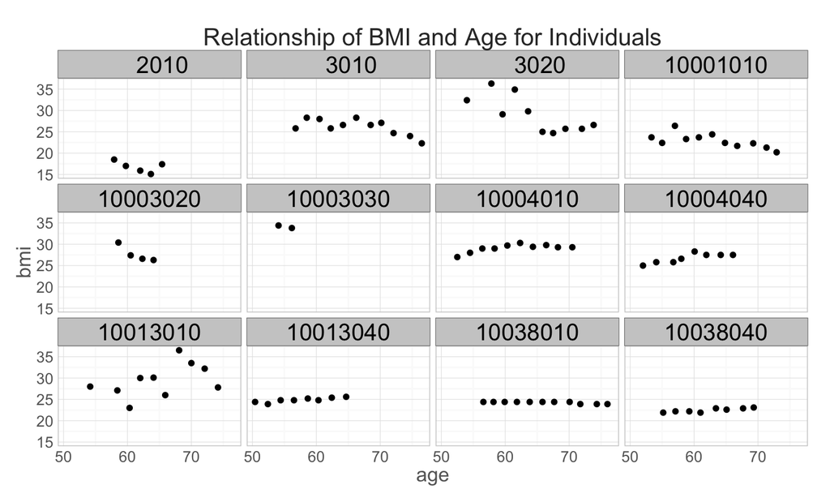

## Linear Mixed Effects Modeling

1. Fixed effects are constant across individuals, and random effects vary.
2. Effects are fixed if they are interesting in themselves or random if there is interest in the underlying population.
3. When a sample exhausts the population, the corresponding variable is fixed; when the sample is a small (i.e., negligible) part of the population the corresponding variable is random.
4. If an effect is assumed to be a realized value of a random variable, it is called a random effect.
5. Fixed effects are estimated using least squares (or, more generally, maximum likelihood) and random effects are estimated with shrinkage.

## Creating Models

1. Fixed Effects Only: Fixed Intercept + Fixed Age
2. Model 0: Random Intercept (BMI)
3. Model 1: Random Intercept (BMI) + Fixed Age
4. Model 2: Random Intercept (BMI) + Fixed Age + Random Age Intercept/Slope
5. Model 3: Random Intercept (BMI) + Fixed Age + Fixed Arthritis + Random Age Intercept/Slope
6. Model 4: Random Intercept (BMI) + Fixed Age + Fixed Arthritis + Interaction Age:Arthritis + Random Age Intercept/Slope

## Graphing Models

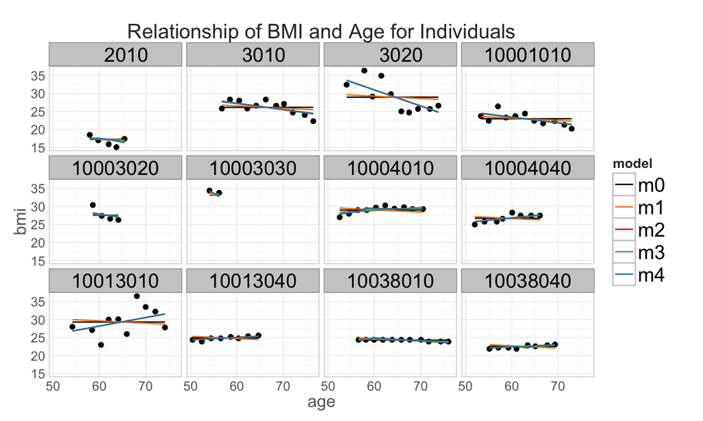

## Model Fit Indices

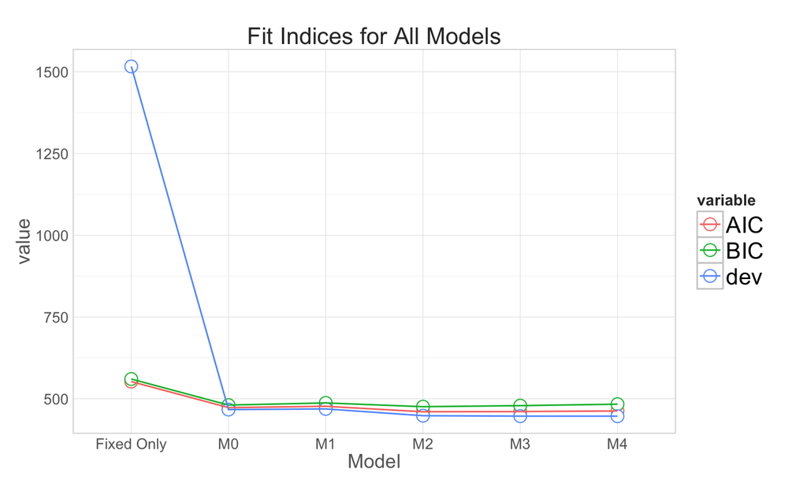

## Conclusions

When predicting BMI in this group, using a model that contains:

-Fixed-effect of age

-Random-effects of individual age slopes/intercepts

-Random intercept (BMI)

Arthritis is not a good variable for predicting BMI

## Further Directions

Nonlinearity

Larger Sample

## References

Gelman, A. (2005). Analysis of variance? Why it is more important than ever. The Annals of Statistics, 1-53.